# R Notebook

# Siri Bafna Homework 3

# Step 1

```r
str(BreastCancer)
```

```
'data.frame':   699 obs. of  11 variables:
 $ Id             : chr  "1000025" "1002945" "1015425" "1016277" ...
 $ Cl.thickness   : Ord.factor w/ 10 levels "1"<"2"<"3"<"4"<..: 5 5 3 6 4 8 1 2 2 4 ...
 $ Cell.size      : Ord.factor w/ 10 levels "1"<"2"<"3"<"4"<..: 1 4 1 8 1 10 1 1 1 2 ...
 $ Cell.shape     : Ord.factor w/ 10 levels "1"<"2"<"3"<"4"<..: 1 4 1 8 1 10 1 2 1 1 ...
 $ Marg.adhesion  : Ord.factor w/ 10 levels "1"<"2"<"3"<"4"<..: 1 5 1 1 3 8 1 1 1 1 ...
 $ Epith.c.size   : Ord.factor w/ 10 levels "1"<"2"<"3"<"4"<..: 2 7 2 3 2 7 2 2 2 2 ...
 $ Bare.nuclei    : Factor w/ 10 levels "1","2","3","4",..: 1 10 2 4 1 10 10 1 1 1 ...
 $ Bl.cromatin    : Factor w/ 10 levels "1","2","3","4",..: 3 3 3 3 3 9 3 3 1 2 ...
 $ Normal.nucleoli: Factor w/ 10 levels "1","2","3","4",..: 1 2 1 7 1 7 1 1 1 1 ...
 $ Mitoses        : Factor w/ 9 levels "1","2","3","4",..: 1 1 1 1 1 1 1 1 5 1 ...
 $ Class          : Factor w/ 2 levels "benign","malignant": 1 1 1 1 1 2 1 1 1 1 ...
```

```r
attach(BreastCancer)
str(BreastCancer)
```

```
'data.frame':   699 obs. of  11 variables:
 $ Id             : chr  "1000025" "1002945" "1015425" "1016277" ...
 $ Cl.thickness   : Ord.factor w/ 10 levels "1"<"2"<"3"<"4"<..: 5 5 3 6 4 8 1 2 2 4 ...
 $ Cell.size      : Ord.factor w/ 10 levels "1"<"2"<"3"<"4"<..: 1 4 1 8 1 10 1 1 1 2 ...
 $ Cell.shape     : Ord.factor w/ 10 levels "1"<"2"<"3"<"4"<..: 1 4 1 8 1 10 1 2 1 1 ...
 $ Marg.adhesion  : Ord.factor w/ 10 levels "1"<"2"<"3"<"4"<..: 1 5 1 1 3 8 1 1 1 1 ...
 $ Epith.c.size   : Ord.factor w/ 10 levels "1"<"2"<"3"<"4"<..: 2 7 2 3 2 7 2 2 2 2 ...
 $ Bare.nuclei    : Factor w/ 10 levels "1","2","3","4",..: 1 10 2 4 1 10 10 1 1 1 ...
 $ Bl.cromatin    : Factor w/ 10 levels "1","2","3","4",..: 3 3 3 3 3 9 3 3 1 2 ...
 $ Normal.nucleoli: Factor w/ 10 levels "1","2","3","4",..: 1 2 1 7 1 7 1 1 1 1 ...
 $ Mitoses        : Factor w/ 9 levels "1","2","3","4",..: 1 1 1 1 1 1 1 1 5 1 ...
 $ Class          : Factor w/ 2 levels "benign","malignant": 1 1 1 1 1 2 1 1 1 1 ...
```

```r
head(BreastCancer)
```

|  | Id | Cl.thickness | Cell.size | Cell.shape | Marg.adhesion | Epith.c.size | Bare.nuclei | Bl.cromatin | Normal.nucleoli | Mitoses | Class |
| --- | --- | --- | --- | --- | --- | --- | --- | --- | --- | --- | --- |
| 1 | 1000025 | 5 | 1 | 1 | 1 | 2 | 1 | 3 | 1 | 1 | benign |
| 2 | 1002945 | 5 | 4 | 4 | 5 | 7 | 10 | 3 | 2 | 1 | benign |
| 3 | 1015425 | 3 | 1 | 1 | 1 | 2 | 2 | 3 | 1 | 1 | benign |
| 4 | 1016277 | 6 | 8 | 8 | 1 | 3 | 4 | 3 | 7 | 1 | benign |
| 5 | 1017023 | 4 | 1 | 1 | 3 | 2 | 1 | 3 | 1 | 1 | benign |
| 6 | 1017122 | 8 | 10 | 10 | 8 | 7 | 10 | 9 | 7 | 1 | malignant |

```r
summary(BreastCancer$Class)
```

```
   benign malignant
      458       241
```

```r
per <- prop.table(table(BreastCancer$Class))
print(per)
```

```
   benign malignant
0.6552217 0.3447783
```

1. There are 699 observations/instances
2. The target column is Class
3. There are 9 total predictors, all of them being either of ordered or nomial type.
4. Malignant takes up 34.5% of the observations.

# Step Two

```r
glm0 <- glm(Class~Cell.size+Cell.shape, data=BreastCancer, family=binomial)
```

```
glm.fit: fitted probabilities numerically 0 or 1 occurred
```

```r
summary(glm0)
```

```
Call:
glm(formula = Class ~ Cell.size + Cell.shape, family = binomial,
    data = BreastCancer)

Deviance Residuals:
    Min       1Q   Median       3Q      Max
-2.6380  -0.0844  -0.0844   0.0000   3.3583

Coefficients:
               Estimate Std. Error z value Pr(>|z|)
(Intercept)     7.77977  757.06736   0.010    0.992
Cell.size.L    10.45177  950.68969   0.011    0.991
Cell.size.Q     0.04064 1479.65505   0.000    1.000
Cell.size.C    10.70546  948.84001   0.011    0.991
Cell.size^4    12.06582 1241.92612   0.010    0.992
Cell.size^5     0.74199  792.70275   0.001    0.999
Cell.size^6    -3.08210 1011.79270  -0.003    0.998
Cell.size^7     7.47104 1044.50458   0.007    0.994
Cell.size^8     5.60143  830.93455   0.007    0.995
Cell.size^9   -10.22144 1812.16583  -0.006    0.995
Cell.shape.L   18.15803 2619.03273   0.007    0.994
Cell.shape.Q    9.14381 1500.17066   0.006    0.995
Cell.shape.C    5.50082 1302.51294   0.004    0.997
Cell.shape^4   -2.23752 2679.86504  -0.001    0.999
Cell.shape^5   -5.76978 3193.32617  -0.002    0.999
Cell.shape^6   -5.58415 2713.54604  -0.002    0.998
Cell.shape^7   -3.94569 1740.80777  -0.002    0.998
Cell.shape^8   -1.82009  827.39680  -0.002    0.998
Cell.shape^9   -0.77209  257.90964  -0.003    0.998

(Dispersion parameter for binomial family taken to be 1)

    Null deviance: 900.53  on 698  degrees of freedom
Residual deviance: 198.66  on 680  degrees of freedom
AIC: 236.66

Number of Fisher Scoring iterations: 19
```

This warning occured because the data model has the appearance of fitted values at only one or zero, they are so close to these values that double precision can’t distinguish them. A solution would be to use linear separation so there can be higher probabilities differentiating 1, and 0. Source: (stat.ethz.ch/pipermail/r-help/2012-March/307352.html)

# Step 3

```r
BreastCancer$Cell.small <- as.factor(c(ifelse (BreastCancer$Cell.size==1, 1, 0)))
BreastCancer$Cell.regular <- as.factor(c(ifelse (BreastCancer$Cell.shape==1, 1, 0)))

summary(BreastCancer$Cell.regular)
```

```
  0   1
346 353
```

```r
summary(BreastCancer$Cell.small)
```

```
  0   1
315 384
```

```r
summary(BreastCancer$Cell.shape)
```

```
  1   2   3   4   5   6   7   8   9  10
353  59  56  44  34  30  30  28   7  58
```

```r
summary(BreastCancer$Cell.size)
```

```
  1   2   3   4   5   6   7   8   9  10
384  45  52  40  30  27  19  29   6  67
```

I think this new step will further help the case of "fitted probabilities with 1 and 0 because it created higher probabilities of them being on only one or zero. Clearly it is one in our situation as you can see how many instances of one there are in Cell.shape and Cell.size compared to the new columns. These additions help show a clearer, more black-and-white differentiation.

# Step 4

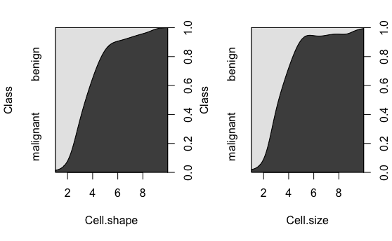

```r
attach(BreastCancer)
par(mfrow=c(1, 2))
cdplot(Class~Cell.shape)
cdplot(Class~Cell.size)
```

In the observations, I can clearly see that both columns are at their critical points at one and then drastically begin to increase/decrease their probability levels. Both these graphs share a severe increase for malignant and decrease for benign at the size = 1 point. Therefore, it makes sense that we used size = 1 to better distribute our data in the new columns.

# Step 5

```r
attach(BreastCancer)
par(mfrow=c(1, 2))
plot(Class, Cell.small, main="CELL SMALL", ylab="", varwidth=TRUE)
plot(Class, Cell.regular, main="CELL REGULAR", ylab="", varwidth=TRUE)
```

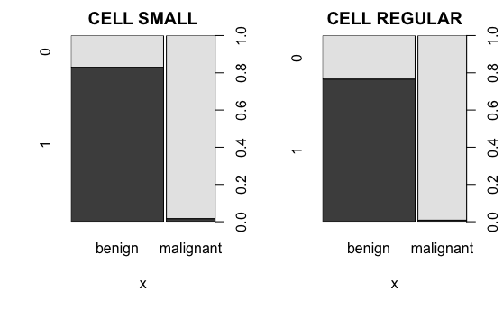

```r
par(mfrow=c(1, 2))
```

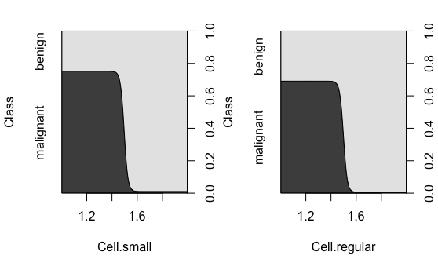

```r
cdplot(Class~Cell.small)
cdplot(Class~Cell.regular)
```

```r
# calculations
smallsum <- sum(BreastCancer$Cell.small==1 & Class=="malignant")
sstotal <- sum(BreastCancer$Cell.small==1)
smallPer <- (smallsum / sstotal) * 100

nsmallsum <- sum(BreastCancer$Cell.small==0 & Class=="malignant")
nstotal <- sum(BreastCancer$Cell.small==0)
nsmallPer <- (nsmallsum / nstotal) * 100

regsum <- sum(BreastCancer$Cell.regular==1 & Class=="malignant")
rtotal <- sum(BreastCancer$Cell.regular==1)
regPer <- (regsum / rtotal) * 100

nregtotal <- sum(BreastCancer$Cell.regular==0 & Class=="malignant")
nrtotal <- sum(BreastCancer$Cell.regular==0)
nregPer <- (nregtotal / nrtotal) * 100
```

After reviewing the graphs as well as the following computations, it’s clear that comparing the benign and malignant variables is very drastic as benign has way higher values, compared to malignant which takes up a very small percentage of the data. With that being said, since the logistic regression is more obvious to predict, and differences are drastic, these two columns would make good predictors. a. 1.04% is small and malignant b. 75.24% is not small and malignant c. .56% is regular and malignant d. 69.08% is not regular and malignant

# Step 6

```r
set.seed(1234)
i <- sample(1:nrow(BreastCancer), .80*nrow(BreastCancer), replace=FALSE)
train <- BreastCancer[i,]
test <- BreastCancer[-i,]
```

# Step 7

```r
glm1 <- glm(Class~Cell.small+Cell.regular, data=train, family="binomial")
summary(glm1)
```

```
Call:
glm(formula = Class ~ Cell.small + Cell.regular, family = "binomial",
    data = train)

Deviance Residuals:
    Min       1Q   Median       3Q      Max
-1.8314  -0.0445  -0.0445   0.6433   3.7198

Coefficients:
              Estimate Std. Error z value Pr(>|z|)
(Intercept)     1.4701     0.1672   8.791  < 2e-16 ***
Cell.small1    -4.6830     0.7411  -6.319 2.64e-10 ***
Cell.regular1  -3.7044     0.7603  -4.873 1.10e-06 ***
---
Signif. codes:  0 ‘***’ 0.001 ‘**’ 0.01 ‘*’ 0.05 ‘.’ 0.1 ‘ ’ 1

(Dispersion parameter for binomial family taken to be 1)

    Null deviance: 721.78  on 558  degrees of freedom
Residual deviance: 255.73  on 556  degrees of freedom
AIC: 261.73

Number of Fisher Scoring iterations: 8
```

1. All predictors, Cell.small and Cell.regular are both really good predictors as noted by the extremely low P-values.
2. Additionally, since the residual deviance is significantly lower than the null deviance, this is more evidence that these predictors are good to use.
3. AIC score, being at 261.73 is a good AIC score as it’s relatively low which means that the likelihood of accuracy for future values is higher.

# Step 8

```r
probs <- predict(glm1, newdata=test, type="response")
pred <- ifelse(probs>.5, 2, 1)
acc <- mean(pred==as.integer(test$Class))
library(e1071)
confusionMatrix(as.factor(pred), as.factor(as.integer(test$Class)))
```

```
Confusion Matrix and Statistics

          Reference
Prediction  1  2
         1 79  2
         2 14 45

               Accuracy : 0.8857
                 95% CI : (0.821, 0.9332)
    No Information Rate : 0.6643
    P-Value [Acc > NIR] : 1.386e-09

                  Kappa : 0.759

 Mcnemar's Test P-Value : 0.00596

            Sensitivity : 0.8495
            Specificity : 0.9574
         Pos Pred Value : 0.9753
         Neg Pred Value : 0.7627
             Prevalence : 0.6643
         Detection Rate : 0.5643
   Detection Prevalence : 0.5786
      Balanced Accuracy : 0.9035

       'Positive' Class : 1
```

# Step 9

```r
coeffs <- glm1$coefficients["Cell.small1"]
```

1. The coefficient I got is -4.683.
2. The coefficient means that is a difference in the log odds of the Class variable, since this is a negative coefficient, it means that the odds of the test are lower than that of the reference group.

```r
exp(coeffs)
```

```
Cell.small1
0.009251231
```

```r
sumOfsm <- sum(Cell.small==1 & Class=="malignant")
sumOfs <- sum(Cell.small==1)
probabilityOfd <- sumOfsm/sumOfs
```

# Step 10

```r
glm_small <- glm(Class~Cell.small, data=train, family="binomial")
glm_regular <- glm(Class~Cell.regular, data=train, family="binomial")
anova(glm_small, glm_regular, glm1)
```

```
Analysis of Deviance Table

Model 1: Class ~ Cell.small
Model 2: Class ~ Cell.regular
Model 3: Class ~ Cell.small + Cell.regular
  Resid. Df Resid. Dev Df Deviance
1       557     300.75
2       557     370.02  0  -69.268
3       556     255.73  1  114.288
```

```r
summary(glm1)
```

```
Call:
glm(formula = Class ~ Cell.small + Cell.regular, family = "binomial",
    data = train)

Deviance Residuals:
    Min       1Q   Median       3Q      Max
-1.8314  -0.0445  -0.0445   0.6433   3.7198

Coefficients:
              Estimate Std. Error z value Pr(>|z|)
(Intercept)     1.4701     0.1672   8.791  < 2e-16 ***
Cell.small1    -4.6830     0.7411  -6.319 2.64e-10 ***
Cell.regular1  -3.7044     0.7603  -4.873 1.10e-06 ***
---
Signif. codes:  0 ‘***’ 0.001 ‘**’ 0.01 ‘*’ 0.05 ‘.’ 0.1 ‘ ’ 1

(Dispersion parameter for binomial family taken to be 1)

    Null deviance: 721.78  on 558  degrees of freedom
Residual deviance: 255.73  on 556  degrees of freedom
AIC: 261.73

Number of Fisher Scoring iterations: 8
```

```r
summary(glm_small)
```

```
Call:
glm(formula = Class ~ Cell.small, family = "binomial", data = train)

Deviance Residuals:
    Min       1Q   Median       3Q      Max
-1.6942  -0.1143  -0.1143   0.7375   3.1729

Coefficients:
            Estimate Std. Error z value Pr(>|z|)
(Intercept)   1.1632     0.1479   7.864 3.71e-15 ***
Cell.small1  -6.1903     0.7246  -8.544  < 2e-16 ***
---
Signif. codes:  0 ‘***’ 0.001 ‘**’ 0.01 ‘*’ 0.05 ‘.’ 0.1 ‘ ’ 1

(Dispersion parameter for binomial family taken to be 1)

    Null deviance: 721.78  on 558  degrees of freedom
Residual deviance: 300.75  on 557  degrees of freedom
AIC: 304.75

Number of Fisher Scoring iterations: 7
```

```r
summary(glm_regular)
```

```
Call:
glm(formula = Class ~ Cell.regular, family = "binomial", data = train)

Deviance Residuals:
    Min       1Q   Median       3Q      Max
-1.5266  -0.1197  -0.1197   0.8645   3.1438

Coefficients:
              Estimate Std. Error z value Pr(>|z|)
(Intercept)     0.7916     0.1292   6.125 9.07e-10 ***
Cell.regular1  -5.7261     0.7212  -7.939 2.04e-15 ***
---
Signif. codes:  0 ‘***’ 0.001 ‘**’ 0.01 ‘*’ 0.05 ‘.’ 0.1 ‘ ’ 1

(Dispersion parameter for binomial family taken to be 1)

    Null deviance: 721.78  on 558  degrees of freedom
Residual deviance: 370.02  on 557  degrees of freedom
AIC: 374.02

Number of Fisher Scoring iterations: 7
```

# Step 11

```r
library(e1071)
nb1 <- naiveBayes(Class~Cell.small + Cell.regular, data=train)
nb1
```

```
Naive Bayes Classifier for Discrete Predictors

Call:
naiveBayes.default(x = X, y = Y, laplace = laplace)

A-priori probabilities:
Y
   benign malignant
0.6529517 0.3470483

Conditional probabilities:
           Cell.small
Y                    0          1
  benign    0.16438356 0.83561644
  malignant 0.98969072 0.01030928

           Cell.regular
Y                    0          1
  benign    0.23835616 0.76164384
  malignant 0.98969072 0.01030928
```

1. 65.3% of the training data is benign.
2. likelihood - 98% of malignant sample = not small
3. likelihood - 98.9% of malignant sample = not regular

# Step 12

```r
p1 <- predict(nb1, newdata=test, type="class")
length(p1)
```

```
[1] 140
```

```r
length(test$Class)
```

```
[1] 140
```

```r
pred2 <- ifelse(p1>.5, 2, 1)
```

```
‘>’ not meaningful for factors
```

```r
table(p1, test$Class)
```

```
p1          benign malignant
  benign        79         2
  malignant     14        45
```

```r
acc2 <- mean(p1==test$Class)
```

I got the same exact result for the table, as well as the accuracy at 88.6, I think this was expected as we are using the same exact predictors with the same exact dataset.

```r
library(caret)
confusionMatrix(as.factor(p1), as.factor(test$Class))
```

```
Confusion Matrix and Statistics

           Reference
Prediction  benign malignant
  benign        79         2
  malignant     14        45

               Accuracy : 0.8857
                 95% CI : (0.821, 0.9332)
    No Information Rate : 0.6643
    P-Value [Acc > NIR] : 1.386e-09

                  Kappa : 0.759

 Mcnemar's Test P-Value : 0.00596

            Sensitivity : 0.8495
            Specificity : 0.9574
         Pos Pred Value : 0.9753
         Neg Pred Value : 0.7627
             Prevalence : 0.6643
         Detection Rate : 0.5643
   Detection Prevalence : 0.5786
      Balanced Accuracy : 0.9035

       'Positive' Class : benign
```

I got the same exact result for the table, as well as the accuracy at 88.6, I think this was expected as we are using the same exact predictors with the same exact dataset. In regards to the confusion matrices, the results were the exact same. From positive class which is benign, to Kappa value and even the CI. The results were the exact same and consistent, this means that the predictors were a solid key to consistency in the model, and produce the exact same likelihood in both Logistic Regression, and Naive Bayes.